# Analyzing Bach

Daniel Roelfs

2019-12-01

## Collecting the data

In my search of a dataset, I found this old website, looking like it last got a major update in 2003, made by what appeared to be a Bach enthousiast called Bryen Travis. I tried to contact him to see if he was interested in collaborating, but I couldn’t get a hold of him. This website contained a list of all works by Bach, with some information about each of them. The website listed a few options, an online browser, a pdf containing slimmed down entries, and two files that I couldn’t get to work, presumably because they were in a format that have presumably become depracated since they were uploaded back in 1996, when the website was created. I could have used the pdf, but since it contained only the BWV number, the title of the piece, and the setting, I had to scrape the data I wanted from the website directly.

## List of BWVs

The website browser contains an index which lists the links to each BWV. Each BWV has its own html page in a subfolder. Thankfully, the html pages were referred by BWV number, and not title, this made my next job a lot easier. I decided to obtain the list of available BWVs from the index page. There in total 1128 BWVs since a new piece was attributed to Bach in 2008. However, the website doesn’t list all of them. The largest number is 1120, but there’s some numbers missing (e.g. 141 and 142), and some duplicate links too (e.g. 147). Therefore I couldn’t just loop from 1 through 1120, but had to extract just the numbers available. The code for this is definitely a bit messy, but let’s have a look anyway. In short, I read the html page as a character vecetor. I get all instances when there’s a link (identified by the `href` tag), convert it from a list to a vector, extract only the unique values, and then select only the links where there’s numbers in front of a `.html` string. I convert it to a character string again, and extract now only the numbers. I’m 99% sure that there is a more efficient way to do this, but this was the best I could think of.

The packages I’ll use in this post are the following. The `{danielR}` package is a package with my personal preferences, such as the origin of the `theme_bach()` function and the colors I’ll use for the plotting, which come from the `{dutchmasters}` package.

```r
library(tidyverse)
library(rvest)
library(waffle)
library(ggmap)
library(danielR)
```

Let’s collect the BWVs:

```r
index_url <- "http://www.bachcentral.com/BWV/index.html"
BWVs <- paste(readLines(index_url), collapse = "\n") %>%
  str_match_all("<a href=\"(.*?)\"") %>%
  unlist() %>%
  unique() %>%
  str_extract_all("[0-9]+.html") %>%
  unlist() %>%
  unique() %>%
  str_extract_all("[0-9]+") %>%
  as.character()
str(BWVs)
```

```
##  chr [1:1075] "1" "2" "3" "4" "5" "6" "7" "8" "9" "10" "11" "12" "13" "14" ...
```

I now have a list of 1075 numbers, corresponding to BWV numbers of which this website has an entry. The next thing I needed to do now was loop over these numbers, navigate to each of the webpages corresponding to that link, and scrape all 1075 webpages individually. This takes a little bit of time, but luckily the author of the pages was very consistent in the setup, so I didn’t need to build in fail-safes or condititions to account for irregularities. Before we’ll do that, I first initialized a data frame with the correct size for speed. I added the column names for convenience too.

```r
col_names <- c("Title", "Subtitle_and_notes",
               "BWV", "BWV_epifix", "CLC_BWV_w_epifix", "belongs after",
               "voices_instruments",
               "category1", "category2", "category3",
               "cantate_cat1", "cantate_cat2")

scraped_data <- data.frame(matrix(ncol = 12, nrow = length(BWVs)))
colnames(scraped_data) <- col_names
```

## Scraping the data

We now have a variable of the same dimensions and column names as I’ll scrape from the website. Now it’s time to loop through the webpages and collect the data. Each webpage contains what looks like a table, but within the table it’s bulleted lists (denoted as `ul`). This might just be how html builds up tables, but I thought it was a bit strange. Nonetheless, it provided me with an easy hook to grab the values. I remove all the white spaces (`\t`), and each new line was denoted by a `\n`, which I used to split the strings into separate values. The advantage of this approach is that when a field is empty, it will still occupy an element in the character array. Then all I needed to do to obtain the values is take every second element and add it as a row to the data frame I created earlier. Now I have a dataset containing the values from all of the 1075 webpages, with which I was quite pleased.

```r
for (i in 1:length(BWVs)) {

  print(sprintf("Scraping data for BWV %s", BWVs[i]))

  url <- sprintf("http://www.bachcentral.com/BWV/%s.html", BWVs[i])
  webpage <- read_html(url)

  text <- webpage %>%
    html_nodes("ul") %>%
    html_text() %>%
    gsub('[\t]', '', .) %>%
    strsplit(., "\\n") %>%
    unlist()

  values <- text[seq(2,length(text),2)]

  scraped_data[i, ] <- values

}
```

With this, I achieved the first goal I had for this little project, which was to find or create a dataset on Bach. Let’s see what it looks like:

```r
str(scraped_data)
```

```
## 'data.frame':    1075 obs. of  12 variables:
##  $ Title             : chr  "Wie schön leuchtet der Morgenstern" "Ach Gott, von Himmel sieh darein" "Ach Gott, wie manches Herzeleid" "Christ lag in Todes Banden" ...
##  $ Subtitle_and_notes: chr  "Kantate am Fest Mariae Verkündigung (Festo annuntiationis Mariae)" "Kantate am zweiten Sonntag nach Trinitatis (Dominica 2 post Trinitatis)" "Kantate am zweiten Sonntag nach Epiphanias (Dominica 2 post Epiphanias)" "Kantate am Osterfest (Feria Paschatos)" ...
##  $ BWV               : chr  "1" "2" "3" "4" ...
##  $ BWV_epifix        : chr  "" "" "" "" ...
##  $ CLC_BWV_w_epifix  : chr  "1" "2" "3" "4" ...
##  $ belongs after     : chr  "" "" "" "" ...
##  $ voices_instruments: chr  "Soli: S, T, B. Chor: S, A, T, B. Instr.: Corno I, II; Ob. da caccia I, II; Viol. conc. I, II; Viol. rip. I, II; Vla.; Cont." "Soli: A, T, B. Chor: S, A, T, B. Instr.: Tromb. I - IV; Ob. I, II; Viol. I, II; Vla.; Cont." "Soli: S, A, T, B. Chor: S, A, T, B. Instr.: Corn…
##  $ category1         : chr  "Vokalwerke" "Vokalwerke" "Vokalwerke" "Vokalwerke" ...
##  $ category2         : chr  "Kantaten" "Kantaten" "Kantaten" "Kantaten" ...
##  $ category3         : chr  "" "" "" "" ...
##  $ cantate_cat1      : chr  "A. Geistliche Kantaten an der Sonn- und Festtagen des Kirchenjahres" "A. Geistliche Kantaten an der Sonn- und Festtagen des Kirchenjahres" "A. Geistliche Kantaten an der Sonn- und Festtagen des Kirchenjahres" "A. Geistliche Kantaten an der Sonn- und Festtagen des Kirc…
##  $ cantate_cat2      : chr  "Mariae Verkundigung" "2. Sonntag nach Trinitatis" "2. Sonntag nach Epiphanias" "1. Osterfesttag" ...
```

All columns are currently character arrays, and this is appropriate for most of them. Although I think the BWV number alone could be a numeric array. Also, some columns are still a bit awkward. This is why I moved on to do another important and satisfying part, cleaning the data.

## Cleaning the data

The character arrays are appropriate, but for further analyes I’d prefer to make at least the categories explicitely factorial. Then I’ll also rename awkwardly named columns, and reorder the columns to start with the BWV instead of the number title.

```r
data <- scraped_data %>%
  mutate(BWV = as.numeric(BWV),
         category1 = factor(category1),
         category2 = factor(category2),
         category3 = factor(category3),
         cantate_cat1 = substring(cantate_cat1,4),
         CLC_BWV_w_epifix = str_replace(CLC_BWV_w_epifix, " ", "")) %>%
  rename(BWV_w_epifix = CLC_BWV_w_epifix) %>%
  select(BWV, BWV_epifix, BWV_w_epifix, everything())
str(data)
```

```
## 'data.frame':    1075 obs. of  12 variables:
##  $ BWV               : num  1 2 3 4 5 6 7 8 9 10 ...
##  $ BWV_epifix        : chr  "" "" "" "" ...
##  $ BWV_w_epifix      : chr  "1" "2" "3" "4" ...
##  $ Title             : chr  "Wie schön leuchtet der Morgenstern" "Ach Gott, von Himmel sieh darein" "Ach Gott, wie manches Herzeleid" "Christ lag in Todes Banden" ...
##  $ Subtitle_and_notes: chr  "Kantate am Fest Mariae Verkündigung (Festo annuntiationis Mariae)" "Kantate am zweiten Sonntag nach Trinitatis (Dominica 2 post Trinitatis)" "Kantate am zweiten Sonntag nach Epiphanias (Dominica 2 post Epiphanias)" "Kantate am Osterfest (Feria Paschatos)" ...
##  $ belongs after     : chr  "" "" "" "" ...
##  $ voices_instruments: chr  "Soli: S, T, B. Chor: S, A, T, B. Instr.: Corno I, II; Ob. da caccia I, II; Viol. conc. I, II; Viol. rip. I, II; Vla.; Cont." "Soli: A, T, B. Chor: S, A, T, B. Instr.: Tromb. I - IV; Ob. I, II; Viol. I, II; Vla.; Cont." "Soli: S, A, T, B. Chor: S, A, T, B. Instr.: Corn…
##  $ category1         : Factor w/ 2 levels "Instrumentalwerke",..: 2 2 2 2 2 2 2 2 2 2 ...
##  $ category2         : Factor w/ 15 levels "Kammermusik",..: 3 3 3 3 3 3 3 3 3 3 ...
##  $ category3         : Factor w/ 26 levels "","Choralbearbeitungen",..: 1 1 1 1 1 1 1 1 1 1 ...
##  $ cantate_cat1      : chr  "Geistliche Kantaten an der Sonn- und Festtagen des Kirchenjahres" "Geistliche Kantaten an der Sonn- und Festtagen des Kirchenjahres" "Geistliche Kantaten an der Sonn- und Festtagen des Kirchenjahres" "Geistliche Kantaten an der Sonn- und Festtagen des Kirchenjahres" .…
##  $ cantate_cat2      : chr  "Mariae Verkundigung" "2. Sonntag nach Trinitatis" "2. Sonntag nach Epiphanias" "1. Osterfesttag" ...
```

Now we have this data, we can do some descriptive visualizations of the data. Over time I hope I can dive into the setting (`voices_instruments`) and disect that, but for now I’ll keep it simple and just do some descriptives.

## Visualizations

The first descritive I wanted to see was what kind of work Bach wrote and in what numbers. First the main category, which differentiates between choral pieces and instrumental pieces.

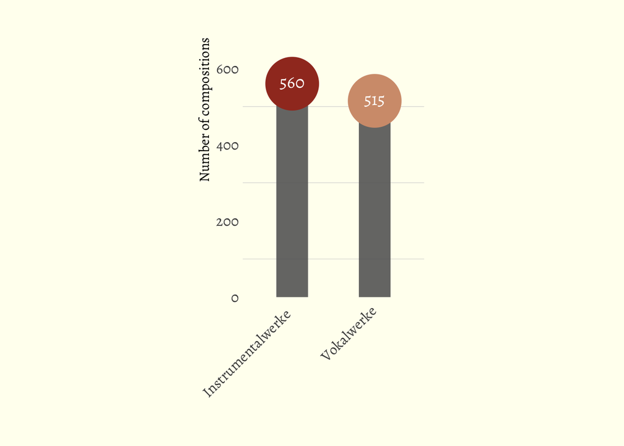

```r
data %>%
  group_by(category1) %>%
  summarise(n = n()) %>%
  ggplot(aes(x = category1, y = n, color = category1)) +
  geom_segment(aes(xend = category1, yend = 0), size = 12,
               color = "grey40", alpha = 0.9) +
  geom_point(size = 20, shape = 16) +
  geom_text(aes(label = n, y = n + 5), color = "white", size = 5, family = "Alegreya") +
  labs(x = NULL,
       y = "Number of compositions") +
  scale_color_daniel(palette = "staalmeesters") +
  scale_y_continuous(limits = c(0,650)) +
  theme_bach(base_family = "Alegreya", grid = "y") +
  theme(
    legend.position = "none",
    aspect.ratio = 3/2,
    axis.text.x = element_text(angle = 45, hjust = 1.1, vjust = 1.15))
```

It seems Bach didn’t have a strong preference for either instrumental or choral music. I suppose he didn’t have infinite freedom with what to compose, since his employer might also request him to compose certain types of music. I wanted to see the same for the secondary category, which differentias between the type of composition (e.g. cantate, passions, organ pieces, symphonies, and so on).

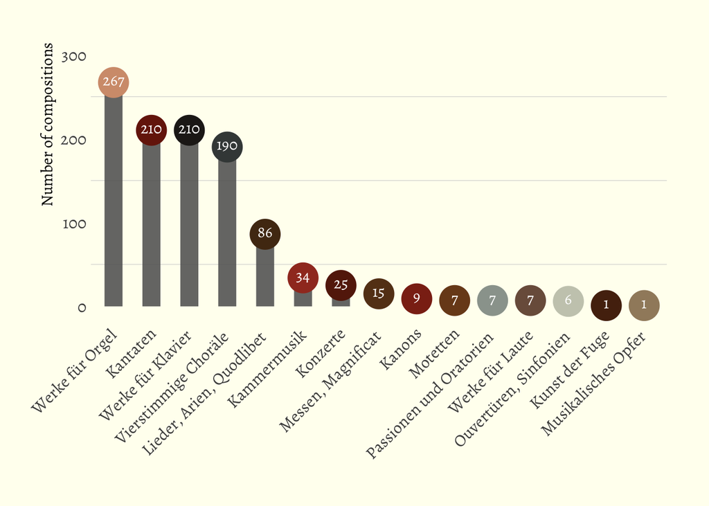

```r
data %>%
  group_by(category2) %>%
  summarise(n = n()) %>%
  ggplot(aes(x = reorder(category2,-n), y = n, color = category2)) +
  geom_segment(aes(xend = category2, yend = 0), size = 6,
               color = "grey40", alpha = 0.9) +
  geom_point(size = 10, shape = 16) +
  geom_text(aes(label = n, y = n + 3), color = "white", size = 4, family = "Alegreya") +
  labs(x = NULL,
       y = "Number of compositions") +
  scale_color_daniel(palette = "staalmeesters") +
  scale_y_continuous(limits = c(-5,300)) +
  theme_bach(base_family = "Alegreya", grid = "y") +
  theme(
    legend.position = "none",
    axis.text.x = element_text(angle = 45, hjust = 1.05, vjust = 1.025)
    )
```

From this it seems that most of the intrumental pieces are made up by just solo pieces for organ and the harpsichord and that the choral pieces are made up mostly by cantates and chorales for four voices. While I appreciate the information dissemination qualities of a barplot (or lollipop plot) like this, in that it’s good in communicating absolute quantities (while I admit that this could also be displayed in a table). One thing it is less good at, is communicating the subjective volume of the works. There’s more than a thousand pieces in the BWV, and I feel that the plots above don’t do a good enough job at communicating just how many pieces this is. Therefore, I created a tile plot (using `{ggwaffle}`), where every tile represents one piece. I colored again based on the secondary category. In order to still maintain the quantities of each category, I added the number of compositions to the legend.

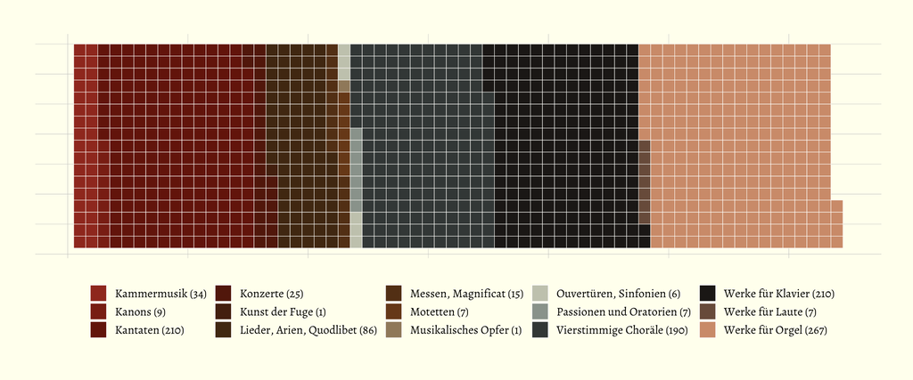

```r
data %>%
  group_by(category2) %>%
  summarise(n = n()) %>%
  mutate(category2 = sprintf("%s (%s)", category2, n)) %>%
  ggplot(aes(fill = category2, values = n)) +
  geom_waffle(n_rows = 17, size = 0.2, colour = "#FFFFFC", flip = FALSE) +
  scale_fill_daniel(palette = "staalmeesters", name = NULL) +
  coord_equal() +
  theme_bach(base_family = "Alegreya", base_size = 14) +
  theme_enhance_waffle() +
  theme(
    legend.position = "bottom"
  )
```

## Scraping Wikipedia

The dataset I just created was comprehensive and clean, but it didn’t contain any information about the musical properties other than the setting. I want to dive into the setting later, but it’s going to be a regular expression hell. I might come back to that later. In the meantime, Wikipedia has a page listing the compositions by Bach too (because of course Wikipedia does). This page contains approximate dates on each composition, as well as the key it was written in. I’m going to scrape this webpage too. The setup of this page was somewhat simpler, so scraping it was slightly simpler.

```r
url <- "https://en.wikipedia.org/wiki/List_of_compositions_by_Johann_Sebastian_Bach"
webpage <- read_html(url)

wikitext <- webpage %>%
  html_nodes(xpath='//*[@id="TOP"]') %>%
  html_table(fill = TRUE) %>%
  as.data.frame()
```

Then I cleaned the data somewhat and extracted the number from the BWV columns.

```r
wikidata <- wikitext %>%
  rename(BWV_full = BWV) %>%
  mutate(BWV = sub('.*(\\d{3}).*', '\\1', BWV_full),
         BWV = parse_integer(BWV)) %>%
  filter(!rev(duplicated(rev(BWV))))
```

Then I merged the data. I lost a number of compositions in the process, but I was okay with it, mostly because it took me too much time and effort to try and fix it. Hurray for laziness. I extracted the year from the slightly messy `Date` column. Some strings in this column contain two dates, one for the first compilation and one for the date of completion. I extracted the last number, the year of completion.

```r
merged_data <- merge(data, wikidata, by = "BWV") %>%
  mutate(year = sub(".*(\\d{4}).*", "\\1", Date),
         year = as.numeric(year),
         age = year - 1685)
```

I noticed that some entries in the `year` column exceeded the year of Bach’s death. Bach died in 1750. I assumed that these years indicated the year of first performance or publication. In this scenario, it would be possible that certain pieces were lost and rediscovered at a later date and only then published. I thought to make a barplot of the number of compositions Bach over the course of his life, trying to see if there was any period where he was particularly productive. I also added some annotations to give the plot some context.

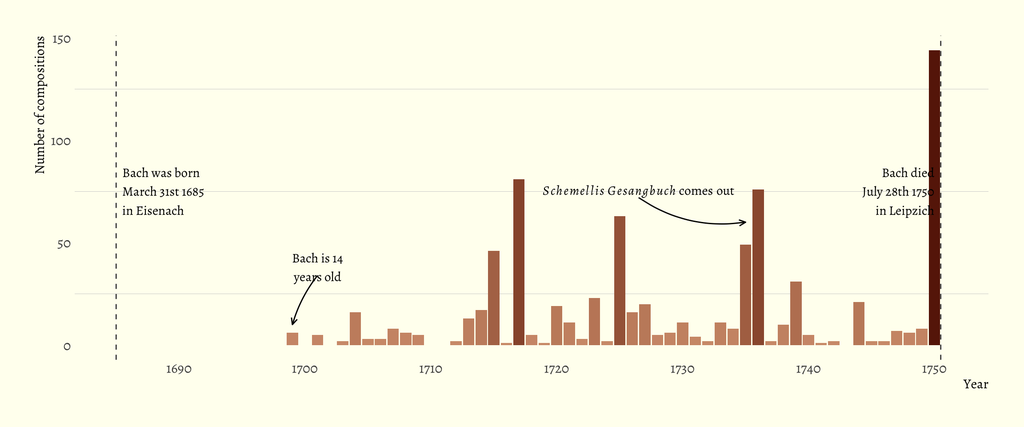

```r
BWVperyear <- merged_data %>%
  filter(!is.na(year)) %>%
  group_by(year,age) %>%
  summarise(n = n())

palette <- daniel_pal("staalmeesters")(6)

annotation1 <- data.frame(
  x = 1701,
  y = 34,
  xend = 1699,
  yend = 10,
  text = "Bach is 14\nyears old"
)

annotation2 <- data.frame(
  x = 1726.5,
  y = 72,
  xend = 1735,
  yend = 60,
  text = "italic(Schemellis~Gesangbuch)~comes~out"
)

ggplot(BWVperyear, aes(x = year, y = n, fill = n)) +
  geom_bar(stat = "identity") +
  geom_vline(xintercept = c(1750.5,1685), linetype = "dashed", color = "grey30") +
  geom_text(data = data.frame(), mapping = aes(x = 1685.5, y = 75, label = "Bach was born\nMarch 31st 1685\nin Eisenach"),
            inherit.aes = FALSE, family = "Alegreya", hjust = 0) +
  geom_text(data = data.frame(), mapping = aes(x = 1750, y = 75, label = "Bach died\nJuly 28th 1750\nin Leipzich"),
            inherit.aes = FALSE, family = "Alegreya", hjust = 1) +
  geom_curve(data = annotation1, mapping = aes(x = x, y = y, xend = xend, yend = yend),
             arrow = arrow(angle = 25, length = unit(6,"pt")),
             curvature = 0.1, inherit.aes = FALSE) +
  geom_text(data = annotation1, mapping = aes(x = x, y = y + 4, label = text),
            family = "Alegreya", inherit.aes = FALSE, parse = FALSE) +
  geom_curve(data = annotation2, mapping = aes(x = x, y = y, xend = xend, yend = yend),
             arrow = arrow(angle = 25, length = unit(6,"pt")),
             curvature = 0.2, inherit.aes = FALSE) +
  geom_text(data = annotation2, mapping = aes(x = x, y = y + 3, label = text),
            family = "Alegreya", inherit.aes = FALSE, parse = TRUE) +
  labs(x = "Year",
       y = "Number of compositions") +
  scale_x_continuous(limits = c(1685,1751), breaks = seq(1690,1750,10)) +
  scale_fill_gradient(low = palette[6], high = palette[2]) +
  theme_bach(base_family = "Alegreya", grid = "y") +
  theme(
    legend.position = 'none'
    )
```

It seems there were two particularly productive years. But since the year column likely indicates year of publication, it’s perhaps more likely that Bach published a collection of pieces in a batch. This is certainly true for the year 1736, when the *Schemellis Gesangbuch* came out, a song book with sacred music, written together with a student of the school he was cantor at: the *Thomasschule* in Leipzich. I’ll come back to this plot later.

The Wikipedia page also contained information on the key of most of the compositions (21 were missing). I was wondering if Bach had a particular preference for a specific key. So I calculated the number of compositions written in each key, and separated based on the first category.

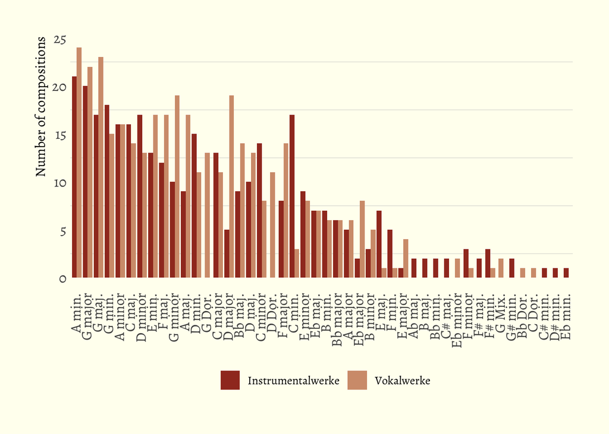

```r
summ_key_cat1 <- merged_data %>%
  group_by(category1, Key) %>%
  summarise(n = n()) %>%
  filter(nchar(Key) > 1) %>%
  mutate(Key = sub("\u266D", "b", Key),
         Key = sub("\U266F", "#", Key),
         Key = ifelse(nchar(Key) > 10, substring(Key,1,nchar(Key)/2), Key)
  ) %>%
  group_by(category1, Key) %>%
  summarise(n = sum(n))

ggplot(summ_key_cat1, aes(x = reorder(Key,-n), y = n, fill = category1)) +
  geom_col(position = position_dodge2(preserve = "single", padding = 0)) +
  labs(x = NULL,
       y = "Number of compositions",
       fill = NULL) +
  scale_fill_daniel(palette = "staalmeesters") +
  theme_bach(base_family = "Alegreya", grid = "y") +
  theme(
    legend.position = "bottom",
    axis.text.x = element_text(angle = 90, hjust = 1, vjust = 0.4)
  )
```

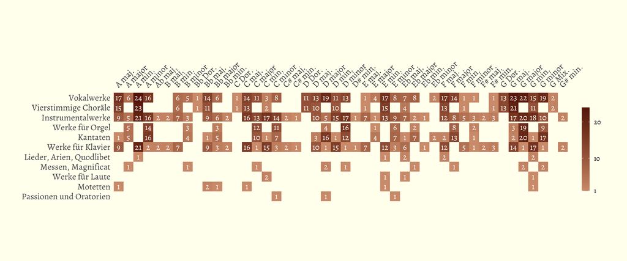

```r
summ_key_cat2 <- merged_data %>%
  group_by(category2, Key) %>%
  summarise(n = n()) %>%
  filter(nchar(Key) > 1) %>%
  mutate(Key = sub("\u266D", "b", Key),
         Key = sub("\U266F", "#", Key),
         Key = ifelse(nchar(Key) > 10, substring(Key,1,nchar(Key)/2), Key)
  ) %>%
  group_by(category2, Key) %>%
  summarise(n = sum(n))

plotdat <- rbind(summ_key_cat1 %>% rename(category2 = category1),
                 summ_key_cat2) %>%
  cbind(gr = c(rep(1,nrow(summ_key_cat1)),
               rep(2,nrow(summ_key_cat2)))
        )

ggplot(plotdat, aes(x = Key, y = reorder(category2,n), fill = n)) +
  geom_tile() +
  geom_text(aes(label = n), family = "Alegreya", color = "white", size = 4) +
  geom_hline(yintercept = 8.5, color = "#FFFFF0", size = 1) +
  labs(x = NULL,
       y = NULL,
       fill = NULL) +
  scale_x_discrete(position = "top") +
  scale_fill_gradient(low = palette[6], high = palette[2], breaks = c(1,seq(10,40,10)),guide = guide_colorbar(barheight = 8, barwidth = 0.75)) +
  coord_fixed() +
  theme_bach(base_family = "Alegreya", grid = FALSE) +
  theme(
    legend.position = "right",
    axis.text.x = element_text(angle = 45, hjust = 0, vjust = -0.5),
    strip.text.x = element_blank(),
    panel.spacing = unit(0, "lines")
  )
```

## Places Bach lived and worked

In addition to this, I also wanted to do some classic journalism. Previously, I looked at Bach most productive years, but since that seemed to be associated with year of publication rather than writing, I thought perhaps comparing the year to the places Bach lived would be more productive. Based on his biography, Bach had a checkered relationship with some of the towns he lived in, either because of personal issues, political issues with church leadership, or something else. I looked up the places Bach lived in, and saved them in a data frame. Using the Google Maps API, I also looked up the coordinates of each city and calculated how long Bach lived everywhere. Bach lived in the same city twice, these occasions I kept separate.

```r
register_google(google_code)
places <- data_frame(
  city = c("Eisenach","Ohrdruf","Lüneburg","Weimar","Arnstadt","Mühlhausen","Weimar","Köthen","Leipzig"),
  year_from = c(1685,1695,1700,1702,1703,1707,1708,1717,1723),
  year_to = c(1695,1700,1702,1703,1707,1708,1717,1723,1750)
) %>%
  mutate_geocode(city) %>%
  mutate(duration = year_to - year_from)
```

Since this time I wanted to visualize whether Bach was more productive in certain places, I recreated the plot from earlier, shaded the background with the city Bach inhabited at the time, and transformed the bars into a density plot, which smoothed over the data and removed the high outliers.

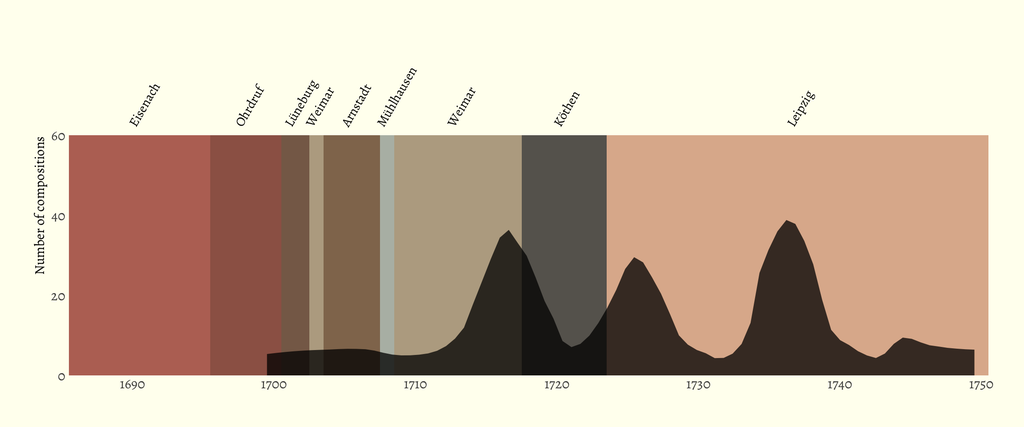

It’s obvious that Bach lived in Leipzich the longest. He had a few productive periods, the last one perhaps being due to the publication of the song book mentioned before.

Lastly, just for fun, I created a map.

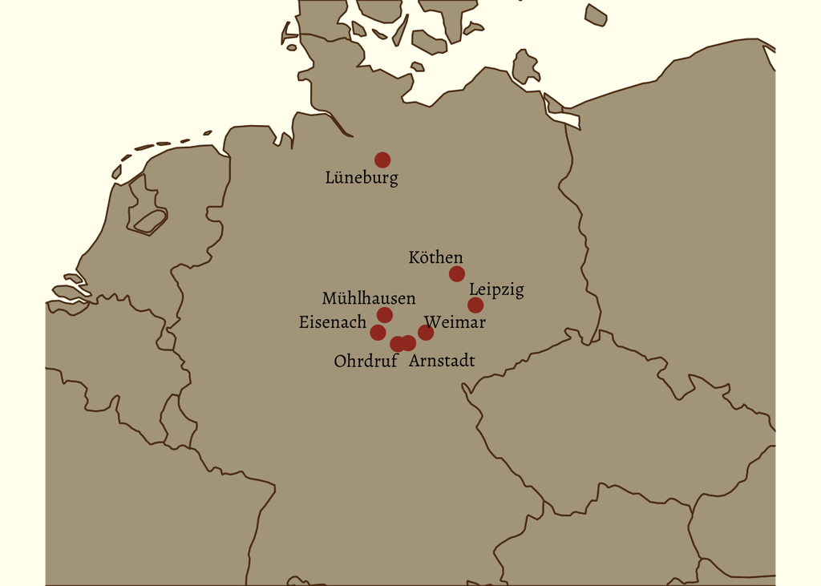

```r
places_unique <- places %>%
  distinct(., city, .keep_all = TRUE)

ggplot(places_unique, aes(x = lon, y = lat)) +
  borders("world", colour = palette[3], fill = palette[4], alpha = 1) +
  geom_point(color = palette[1], size = 4) +
  ggrepel::geom_text_repel(aes(label = city), force = 1, size = 4,
                           seed = 2345, point.padding = 0.2,
                           family = "Alegreya") +
  coord_quickmap(xlim = c(4, 18), ylim = c(48, 55)) +
  theme_void()
```

This was a fun exercise in scraping data and trying out new things with visualization!

## Future plans

In the future, I hope to do some more in-depth statistical analysis on any of this. Perhaps I’ll finally dive into the setting, there are some cool more complex visualization opportunities there. With this I could also make a Shiny app where one can select the voices you are interested in, and it will show you the pieces that are written for that combination of voices, or select the time of the year, and it will return the pieces written for that part of the Christian calendar (i.e. Advent, Epiphany, or Easter). Most importantly, I might actually do some statistics, instead of just visualizing data. Creating nice figures is great fun, but the real interest lies in perfoming adequate statistical tests, though I still need to think about what statistics would be appropriate for this context. Any tips or requests?